# Assignment 2: Hand Gesture Recognition [50 Pt]

### Part (i) - [2pt EXPLORATORY]

Here is the code to load the AlexNet network, with pretrained weights. When you first run the code, PyTorch will download the pretrained weights from the internet.

```python
import torchvision.models
alexnet = torchvision.models.alexnet(pretrained=True)
use_cuda = True
if use_cuda and torch.cuda.is_available():
  alexnet.cuda()
  print('Alexnet on GPU ...')
```

The alexnet model is split up into two components: *alexnet.features* and *alexnet.classifier*. The first neural network component, *alexnet.features*, is used to compute convolutional features, which are taken as input in *alexnet.classifier*.

The neural network alexnet.features expects an image tensor of shape Nx3x224x224 as input and it will output a tensor of shape Nx256x6x6 . (N = batch size).

Compute the AlexNet features for each of your training, validation, and test data. Here is an example code snippet showing how you can compute the AlexNet features for some images (your actual code might be different):

```python
# img = ... a PyTorch tensor with shape [N,3,224,224] containing hand images ...
def extract_features(model, data_loader):

    features = []
    labels = []

    with torch.no_grad():
        for inputs, targets in data_loader:
            if use_cuda and torch.cuda.is_available():
              inputs = inputs.cuda()
              targets = targets.cuda()
            features_batch = model.features(inputs)
            features.append(features_batch)
            labels.append(targets)
    feats, labels = torch.cat(features), torch.cat(labels)
    print("Tensor Size:",feats.size())
    return feats, labels

batch_size = 1942 #entire training set
val_split = 0.1
test_split = 0.1

train_loader, val_loader, test_loader, _ = get_data_loader(dataset_root, batch_size, val_split, test_split)

train_features, train_labels = extract_features(alexnet, train_loader)
val_features, val_labels = extract_features(alexnet, val_loader)
test_features, test_labels = extract_features(alexnet, test_loader)
```

```
Train size: 1947
Val size: 240
Test size: 240
Tensor Size: torch.Size([1942, 256, 6, 6])
Tensor Size: torch.Size([240, 256, 6, 6])
Tensor Size: torch.Size([240, 256, 6, 6])
```

**Save the computed features**. You will be using these features as input to your neural network in Part (ii), and you do not want to re-compute the features every time. Instead, run *alexnet.features* once for each image, and save the result.

```python
# TO BE COMPLETED
#check size

torch.save(train_features,'training_features')
torch.save(val_features,'val_features')
torch.save(test_features,'test_features')
```

### Part (ii) - [2pt MODEL]

Build a convolutional neural network model that takes as input these AlexNet features, and makes a prediction. Your model should be a subclass of nn.Module.

Explain your choice of neural network architecture: how many layers did you choose? What types of layers did you use: fully-connected or convolutional? What about other decisions like pooling layers, activation functions, number of channels / hidden units in each layer?

Here is an example of how your model may be called:

```python
# TO BE COMPLETED
class AlexClassifier(nn.Module):
  def __init__(self):
      super(AlexClassifier, self).__init__()
      self.name = "AlexClassifier"
      self.fc1 = nn.Linear(6*6*256, 9) #43,200 params

  def forward(self, x):
      x = x.view(-1, 6*6*256)
      x = self.fc1(x)
      # Add in softmax
      x = nn.functional.softmax(x, dim=1)
      return x
```

```python
'''
PROVIDE YOUR ANSWER BELOW
Instead of having 3*224*224 = 150,528 values per image to process, we now
only have 256*6*6 = 9,216, a significant decrease from the previous training set.
Since I'm assuming that much of the feature extraction has been done using alexnet,
my network's main task (I imagine) is dimensionality reduction. For this purpose
I'm going to build an incredibly simple network: 1 fully connected layer to map
the features to the 9 possible class outputs. This might be too simple, but I
don't think there's any need for convolutional layers here since that's what
Alexnet is for. If training performs poorly, I'll come back and try adding a
layer or 2.



'''
```

### Part (iii) - [1pt MODEL]

Train your new network, including any hyperparameter tuning. Plot and submit the training curve of your best model only.

Note: Depending on how you are caching (saving) your AlexNet features, PyTorch might still be tracking updates to the **AlexNet weights**, which we are not tuning. One workaround is to convert your AlexNet feature tensor into a numpy array, and then back into a PyTorch tensor.

```python
# from numpy.lib.twodim_base import triu_indices_from
from torch.utils.data import TensorDataset

# TO BE COMPLETED
#convert to numpy array, then back to torch tensor, and merge with labels
if use_cuda and torch.cuda.is_available():
  train_features = train_features.cpu()
  val_features = val_features.cpu()
  test_features = test_features.cpu()
train_tensor = TensorDataset(torch.from_numpy(train_features.detach().numpy()), train_labels)
val_tensor = TensorDataset(torch.from_numpy(val_features.detach().numpy()), val_labels)
test_tensor = TensorDataset(torch.from_numpy(test_features.detach().numpy()), test_labels)

#Create data loaders
batch_size = 1942
train_alex_loader = torch.utils.data.DataLoader(train_tensor, batch_size=batch_size, shuffle=True)
val_alex_loader = torch.utils.data.DataLoader(train_tensor, batch_size=batch_size, shuffle=True)
test_alex_loader = torch.utils.data.DataLoader(train_tensor, batch_size=batch_size, shuffle=True)
```

```
CUDA is not available.  Training on CPU ...
epoch: 0, Training Accuracy: 0.12100926879505665, Training Loss: 0.0011331682715921766, Validation Accuracy: 0.44026776519052524
epoch: 1, Training Accuracy: 0.44026776519052524, Training Loss: 0.0010508426554293882, Validation Accuracy: 0.5638516992790937
epoch: 2, Training Accuracy: 0.5638516992790937, Training Loss: 0.000980200470414638, Validation Accuracy: 0.63697219361483
epoch: 3, Training Accuracy: 0.63697219361483, Training Loss: 0.0009377595693272002, Validation Accuracy: 0.641091658084449
epoch: 4, Training Accuracy: 0.641091658084449, Training Loss: 0.0009117297728447173, Validation Accuracy: 0.7734294541709578
epoch: 5, Training Accuracy: 0.7734294541709578, Training Loss: 0.0008685817801989192, Validation Accuracy: 0.8274974253347065
epoch: 6, Training Accuracy: 0.8274974253347065, Training Loss: 0.0008382373686062688, Validation Accuracy: 0.8439752832131823
epoch: 7, Training Accuracy: 0.8439752832131823, Training Loss: 0.0008314882935505325, Validation Accuracy: 0.8661174047373842
epoch: 8, Training Accuracy: 0.8661174047373842, Training Loss: 0.0008093902551550821, Validation Accuracy: 0.8733264675592173
epoch: 9, Training Accuracy: 0.8733264675592173, Training Loss: 0.0008007123467851004, Validation Accuracy: 0.8831101956745623
epoch: 10, Training Accuracy: 0.8831101956745623, Training Loss: 0.0007932604157224866, Validation Accuracy: 0.8892893923789907
epoch: 11, Training Accuracy: 0.8892893923789907, Training Loss: 0.0007848896155273877, Validation Accuracy: 0.8959835221421215
epoch: 12, Training Accuracy: 0.8959835221421215, Training Loss: 0.0007791514868102776, Validation Accuracy: 0.9042224510813595
epoch: 13, Training Accuracy: 0.9042224510813595, Training Loss: 0.000773874849050347, Validation Accuracy: 0.9098867147270855
epoch: 14, Training Accuracy: 0.9098867147270855, Training Loss: 0.00076872705799421, Validation Accuracy: 0.9104016477857878
epoch: 15, Training Accuracy: 0.9104016477857878, Training Loss: 0.0007653840415632442, Validation Accuracy: 0.911946446961895
epoch: 16, Training Accuracy: 0.911946446961895, Training Loss: 0.0007632256904664909, Validation Accuracy: 0.9186405767250257
epoch: 17, Training Accuracy: 0.9186405767250257, Training Loss: 0.0007604871302014399, Validation Accuracy: 0.9222451081359423
epoch: 18, Training Accuracy: 0.9222451081359423, Training Loss: 0.0007569255838678991, Validation Accuracy: 0.9263645726055613
epoch: 19, Training Accuracy: 0.9263645726055613, Training Loss: 0.000753650213491045, Validation Accuracy: 0.9294541709577755
epoch: 20, Training Accuracy: 0.9294541709577755, Training Loss: 0.0007514267331171477, Validation Accuracy: 0.9299691040164778
epoch: 21, Training Accuracy: 0.9299691040164778, Training Loss: 0.0007500727684932437, Validation Accuracy: 0.9325437693099897
epoch: 22, Training Accuracy: 0.9325437693099897, Training Loss: 0.0007489271438944352, Validation Accuracy: 0.9340885684860968
epoch: 23, Training Accuracy: 0.9340885684860968, Training Loss: 0.0007475170121747851, Validation Accuracy: 0.9376930998970134
epoch: 24, Training Accuracy: 0.9376930998970134, Training Loss: 0.0007458521949029485, Validation Accuracy: 0.9397528321318228
epoch: 25, Training Accuracy: 0.9397528321318228, Training Loss: 0.0007441976902781997, Validation Accuracy: 0.94129763130793
epoch: 26, Training Accuracy: 0.94129763130793, Training Loss: 0.000742702479220075, Validation Accuracy: 0.9443872296601442
epoch: 27, Training Accuracy: 0.9443872296601442, Training Loss: 0.0007412922247308167, Validation Accuracy: 0.946961894953656
epoch: 28, Training Accuracy: 0.946961894953656, Training Loss: 0.0007398240843712976, Validation Accuracy: 0.9485066941297632
epoch: 29, Training Accuracy: 0.9485066941297632, Training Loss: 0.0007382934542812107, Validation Accuracy: 0.9505664263645726
epoch: 30, Training Accuracy: 0.9505664263645726, Training Loss: 0.0007368873739586309, Validation Accuracy: 0.9536560247167868
epoch: 31, Training Accuracy: 0.9536560247167868, Training Loss: 0.0007358364661125395, Validation Accuracy: 0.9541709577754892
epoch: 32, Training Accuracy: 0.9541709577754892, Training Loss: 0.0007351228677649453, Validation Accuracy: 0.9546858908341915
epoch: 33, Training Accuracy: 0.9546858908341915, Training Loss: 0.0007344787570155857, Validation Accuracy: 0.9557157569515963
epoch: 34, Training Accuracy: 0.9557157569515963, Training Loss: 0.0007337599409596436, Validation Accuracy: 0.9577754891864058
epoch: 35, Training Accuracy: 0.9577754891864058, Training Loss: 0.0007330406338252688, Validation Accuracy: 0.9582904222451082
epoch: 36, Training Accuracy: 0.9582904222451082, Training Loss: 0.0007324175166789094, Validation Accuracy: 0.9582904222451082
epoch: 37, Training Accuracy: 0.9582904222451082, Training Loss: 0.0007318641940548049, Validation Accuracy: 0.9588053553038105
epoch: 38, Training Accuracy: 0.9588053553038105, Training Loss: 0.0007312801176438494, Validation Accuracy: 0.9598352214212152
```

[output cut: 96 more lines]

```
epoch: 135, Training Accuracy: 0.974768280123584, Training Loss: 0.0007199136776241534, Validation Accuracy: 0.974768280123584
epoch: 136, Training Accuracy: 0.974768280123584, Training Loss: 0.0007198952007981211, Validation Accuracy: 0.974768280123584
epoch: 137, Training Accuracy: 0.974768280123584, Training Loss: 0.0007198763556632642, Validation Accuracy: 0.974768280123584
epoch: 138, Training Accuracy: 0.974768280123584, Training Loss: 0.0007198582471460564, Validation Accuracy: 0.974768280123584
epoch: 139, Training Accuracy: 0.974768280123584, Training Loss: 0.0007198410594009101, Validation Accuracy: 0.974768280123584
epoch: 140, Training Accuracy: 0.974768280123584, Training Loss: 0.0007198255904302783, Validation Accuracy: 0.974768280123584
epoch: 141, Training Accuracy: 0.974768280123584, Training Loss: 0.0007198113491557285, Validation Accuracy: 0.974768280123584
epoch: 142, Training Accuracy: 0.974768280123584, Training Loss: 0.0007197980286532401, Validation Accuracy: 0.974768280123584
epoch: 143, Training Accuracy: 0.974768280123584, Training Loss: 0.0007197851992291844, Validation Accuracy: 0.974768280123584
epoch: 144, Training Accuracy: 0.974768280123584, Training Loss: 0.0007197723698051287, Validation Accuracy: 0.974768280123584
epoch: 145, Training Accuracy: 0.974768280123584, Training Loss: 0.0007197596631506813, Validation Accuracy: 0.974768280123584
epoch: 146, Training Accuracy: 0.974768280123584, Training Loss: 0.0007197467723418215, Validation Accuracy: 0.974768280123584
epoch: 147, Training Accuracy: 0.974768280123584, Training Loss: 0.0007197338201481577, Validation Accuracy: 0.974768280123584
epoch: 148, Training Accuracy: 0.974768280123584, Training Loss: 0.0007197211134937102, Validation Accuracy: 0.974768280123584
epoch: 149, Training Accuracy: 0.974768280123584, Training Loss: 0.0007197087137632832, Validation Accuracy: 0.974768280123584
```

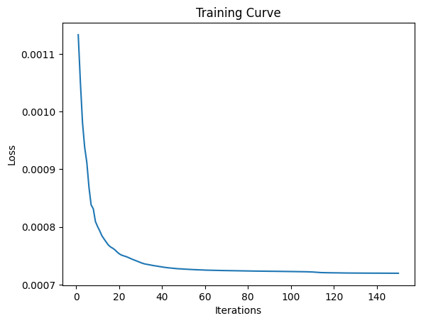

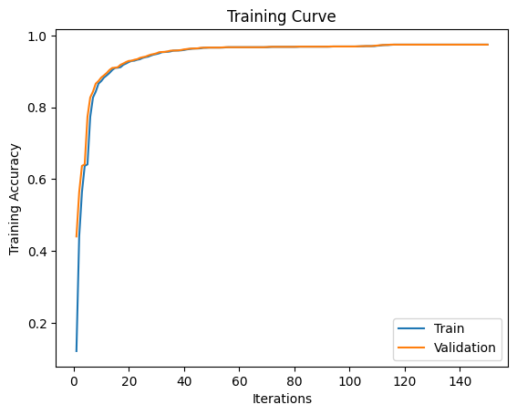

```
Final Training Accuracy: 0.974768280123584
Final Validation Accuracy: 0.974768280123584
Highest Validation Accuracy:  0.974768280123584
```

```python
lr = 0.001
use_cuda = True

model = AlexClassifier()
if use_cuda and torch.cuda.is_available():
  model.cuda()
  print('CUDA is available!  Training on GPU ...')
else:
  print('CUDA is not available.  Training on CPU ...')
#proper model
train(model, train_alex_loader, val_alex_loader, lr = lr, training_batch_size = batch_size, num_epochs=150)
```